# lab6

Yuchen Song_201830360498 - Xuewen Wang_201830120252

2021/10/13

### Data Loading and Pre-processing

```r
load(url("http://www.openintro.org/stat/data/ames.RData"))
population = ames$Gr.Liv.Area
```

### Ex1

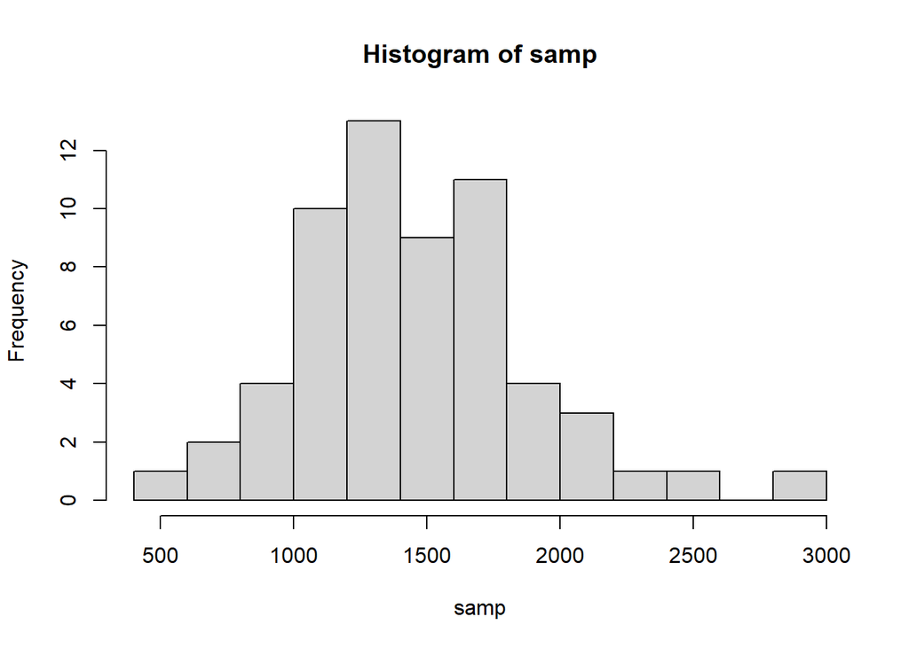

```r
set.seed(2152)
samp = sample(population, 60)
hist(samp,breaks = 10)
```

```r
summary(samp)
```

```
##    Min. 1st Qu.  Median    Mean 3rd Qu.    Max.
##     498    1137    1411    1453    1716    2840
```

The distribution is approximately unimodal Normal distribution with center at about 1400, and there are outliers at some point about 3000.

### Ex2

The distribution spreads from 500 to 3000, and it is nearly symmetrical.  
We would like to choose the “typical” to be 1411, which is the median.  
To us, the size means the average living area in Ames, it is more accurate than the mean because there are outliers.

### Ex3

It cannot be identical since we set the different sample seed.  
However, it may be similar because we select the sample from the same data set and the point estimate is likely to be unbiased.

### Ex4

```r
sample_mean = mean(samp)
sample_deviation = sd(samp)
sde = sample_deviation/sqrt(60)
lower = sample_mean - 1.96 * sde
upper = sample_mean + 1.96 * sde
sprintf("The 95%% confidence interval for the true average size of houses in Ames is [%f,%f]",lower,upper)
```

```
## [1] "The 95% confidence interval for the true average size of houses in Ames is [1343.076633,1562.390033]"
```

### Ex5

“95% confidence” means that we have 95% confidence that our estimation is correct.  
In other words, the chance for a case that does not lie in our estimate interval only takes about 5%.

### Ex6

```r
mean(population)
```

```
## [1] 1499.69
```

```r
set.seed(2220)
samp = sample(population, 60)
sample_mean = mean(samp)
sample_deviation = sd(samp)
sde = sample_deviation/sqrt(60)
lower = sample_mean - 1.96 * sde
upper = sample_mean + 1.96 * sde
c(lower, upper)
```

```
## [1] 1430.129 1646.837
```

The value of population mean lies in the estimate interval in both cases.

### Ex7

We expect about 95% of these intervals captures the true population mean.  
Because we estimate that it is the 95% confidence interval. If we estimate many times, our estimation is separate, so the probability for there estimated interval to capture the true population mean is still 95%.

### Ex8

[figure not shown]

```r
samp_mean = rep(NA, 100)
samp_sd = rep(NA, 100)
n = 60
for(i in 1:100){
  set.seed(i)
  samp = sample(population, n) # obtain a sample of size n = 60 from the population
  samp_mean[i] = mean(samp)    # save sample mean in ith element of samp_mean
  samp_sd[i] = sd(samp)        # save sample sd in ith element of samp_sd
}
lower_vector = samp_mean - 1.96 * samp_sd / sqrt(n)
upper_vector = samp_mean + 1.96 * samp_sd / sqrt(n)
plot_ci(lower_vector, upper_vector, mean(population))
```

### Ex9

We choose the confidence level of 99%, whose critical value is 2.575.

### Ex10

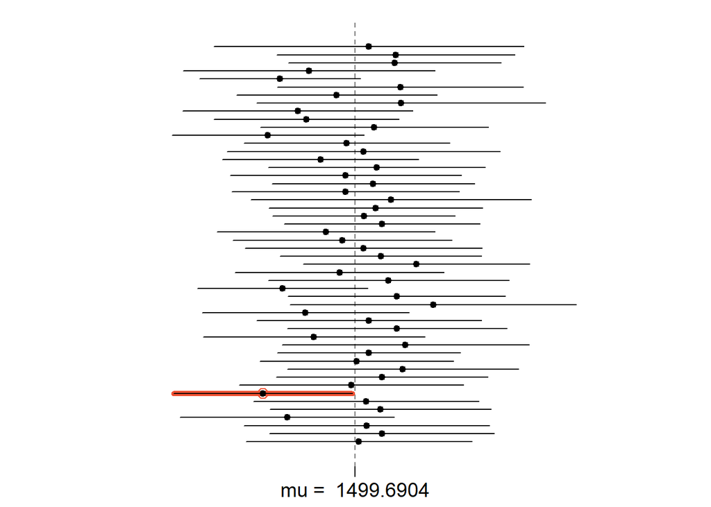

```r
samp_mean = samp_mean[1:50]
samp_sd = samp_sd[1:50]
lower_vector = samp_mean - 2.575 * samp_sd / sqrt(n)
upper_vector = samp_mean + 2.575 * samp_sd / sqrt(n)
plot_ci(lower_vector, upper_vector, mean(population))
```

The percentage is 49/50=98%, which is very close to 99(but not equal).